# Sparcc Simulation 2

Brian Richardson

04/03/2024

```r
rm(list = ls())
library(dplyr)
library(tidyverse)
library(ggplot2)
library(ggh4x)
library(scales)
library(ggthemes)
library(kableExtra)
```

## Simulation Setup

The goal of this program is to evaluate the performance of the semiparametric efficient estimator $\widehat{\pmb{\beta}}_{sp}$ using simulations in the following setting:

- $Z \sim \textrm{Bernoulli}(0.5)$,
- $X|Z \sim \textrm{beta}(\alpha_1 + \alpha_2 Z, \alpha_3 + \alpha_4 Z)$,
- $C|Z \sim \textrm{beta}(\gamma_1 + \gamma_2 Z, \gamma_3 + \gamma_4 Z)$,
- $Y|X,Z \sim N(\beta_0 + \beta_1X + \beta_2Z, \sigma^2)$.

The assumption that $Y|X,Z$ follows a normal distribution allows us to use Gaussian quadrature to efficiently solve integrals with respect to $y$.

In these simulations, we vary the censoring probability $q=\textrm{P}(X>C)$.

We also vary which nuisance distributions are correct by modeling $X|Z$ (or $C|Z$) as beta with estimated parameters $\pmb{\alpha}, \pmb{\gamma}$ (correct) or uniform with no parameters estimated (incorrect).

For each simulation, we generate a data set of size $n$ then compute the complete case estimator $\widehat{\pmb{\beta}}_{cc}$, the oracle estimator $\widehat{\pmb{\beta}}_{or}$, the parametric MLE $\widehat{\pmb{\beta}}_{ml}$, and the semiparametric efficient estimator $\widehat{\pmb{\beta}}_{sp}$.

```r
# true (beta0, beta2)
B13 <- c(1, 10, 2, log(4))

# load simulation results from each of 10 clusters
sim.out.list <- lapply(
  X = 0:9,
  FUN = function(clust) {
    cbind(clust,
          read.csv(paste0(
            "sim2_data/v9/sd",
            clust, ".csv")))
  })

# combine simulation results into 1 data frame
sim.out <- bind_rows(sim.out.list)

colnames(sim.out) <- gsub(".B", "", colnames(sim.out))
colnames(sim.out) <- gsub("B2", "trueB2", colnames(sim.out))

# make long data frame
sim.out.long <- sim.out %>%
  pivot_longer(cols = starts_with("B"),
               names_to = "method.param",
               values_to = "estimate") %>%
    mutate(method = factor(substr(method.param, 2, 3),
                           levels = c("or", "cc", "ml", "sp")),
           x.correct = factor(x.correct,
                              levels = c(1, 0)),
           c.correct = factor(c.correct,
                              levels = c(1, 0)),
           param = factor(substr(method.param, 4, 4)),
           B.true = ifelse(param == 2, trueB2,
                    ifelse(param == 4, log(s2),
                           B13[param])))
```

## Simulation Results

#### Errors in Simulations

We first look at which simulation settings lead to errors.

```r
# check for simulations with errors
sim.out.long %>%
  filter(param == 1) %>%
  group_by(q, n, x.correct, c.correct, method, trueB2, s2, c.gamma) %>%
  summarize(prop.error = mean(is.na(estimate))) %>%
  filter(prop.error > 0) %>%
  kable(digits = 3) %>%
  kable_styling("striped")
```

| q | n | x.correct | c.correct | method | trueB2 | s2 | c.gamma | prop.error |
| --- | --- | --- | --- | --- | --- | --- | --- | --- |

In these simulations, all models converged with no errors.

```r
# extract simulation parameters
q <- unique(sim.out$q)
n <- unique(sim.out$n)
s2 <- unique(sim.out$s2)
trueB2 <- unique(sim.out$trueB2)
c.gamma <- unique(sim.out$c.gamma)
x.correct <- unique(sim.out$x.correct)
c.correct <- unique(sim.out$c.correct)
mx <- unique(sim.out$mx)
mc <- unique(sim.out$mc)
my <- unique(sim.out$my)
n.rep <- nrow(sim.out) /
  n_distinct(dplyr::select(sim.out, q, n, x.correct, c.correct,
                           mx, mc, my, s2, trueB2, c.gamma))

# make labels for plots
method.labs <- c("Oracle",
                 "Complete Case",
                 "Parametric MLE",
                 "Semiparametric")

names(method.labs) <- c("or", "cc", "ml", "sp")

q.labs <- paste0("q = ", q)
names(q.labs) <- q

n.labs <- paste0("n = ", n)
names(n.labs) <- n

s2.labs <- paste0("s2 = ", s2)
names(s2.labs) <- s2

trueB2.labs <- paste0("B2 = ", trueB2)
names(trueB2.labs) <- trueB2

c.gamma.labs <- paste0("c.gamma = ", c.gamma)
names(c.gamma.labs) <- c.gamma

specx.labs <- c("X Correct", "X Incorrect")
names(specx.labs) <- x.correct

specc.labs <- c("C Correct", "C Incorrect")
names(specc.labs) <- c.correct

mx.labs <- paste0("mx = ", mx)
names(mx.labs) <- mx

mc.labs <- paste0("mc = ", mc)
names(mc.labs) <- mc

my.labs <- paste0("my = ", my)
names(my.labs) <- my

param.labs <- c("\u03B20", "\u03B21", "\u03B22", "log\u03C3\u00B2")

# colorblind friendly pallette
#pal_light <- cbbPalette <- c('#BBBBBB', '#228833', '#4477AA', '#AA3377')
#pal_dark <- cbbPalette <- c('#5d5d5d', '#114419', '#223b55', '#55193b')
pal_light <- c('#EE6677', '#228833', '#4477AA', '#CCBB44', '#66CCEE', '#AA3377', '#BBBBBB')
pal_dark <- c('#991122', '#114419', '#223b55', '#6b611d', '#117799', '#55193b', '#5d5d5d')
```

```r
# boxplot of simulated estimates
make.est.plot <- function(param., est_cutoff = Inf,
                          trueB2. = trueB2, s2. = s2, c.gamma. = c.gamma,
                          q. = q, n. = n) {

  sim.out.long %>%
    filter(param == param.,
           trueB2 %in% trueB2.,
           s2 %in% s2.,
           c.gamma %in% c.gamma.,
           q %in% q.,
           n %in% n.,
           abs(estimate - B.true) < est_cutoff) %>%
    ggplot(aes(y = estimate,
               color = method,
               fill = method)) +
    geom_boxplot() +
    geom_hline(aes(yintercept = B.true),
               linetype = "dashed",
               linewidth = 0.6,
               color = pal_light[4]) +
    facet_nested(s2 + c.gamma ~ x.correct + c.correct,
                 scales = "free",
                 labeller = labeller(n = n.labs,
                                     q = q.labs,
                                     trueB2 = trueB2.labs,
                                     s2 = s2.labs,
                                     c.gamma = c.gamma.labs,
                                     x.correct = specx.labs,
                                     c.correct = specc.labs)) +
    labs(y = "Parameter Estimate",
         fill = "Method",
         color = "Method") +
    ggtitle(paste0("Empirical Distribution of Parameter Estimates for ",
                   param.labs[param.]),
            subtitle = paste0(#"true B2 = ", trueB2., "; ",
                              #"s2 = ", s2., "; ",
                              #"censoring proportion q = ", q., "; ",
                              n.rep, " replicates per setting")) +
    theme_bw() +
    theme(axis.ticks.x = element_blank(),
          axis.text.x = element_blank(),
          axis.title.x = element_blank()) +
    scale_fill_manual(values = pal_light[c(1, 2, 3, 5, 6)],
                      labels = method.labs) +
    scale_color_manual(values = pal_dark[c(1, 2, 3, 5, 6)],
                      labels = method.labs)
}
```

#### Primary Simulation Results

The most interesting/important results are for the parameter estimates of the coefficient $\beta_1$ for $X$, and with a high censoring rate of $q = 0.8$. Below are those results, summarized with (i) a boxplot of estimates and (ii) a table with bias, variance, and MSE.

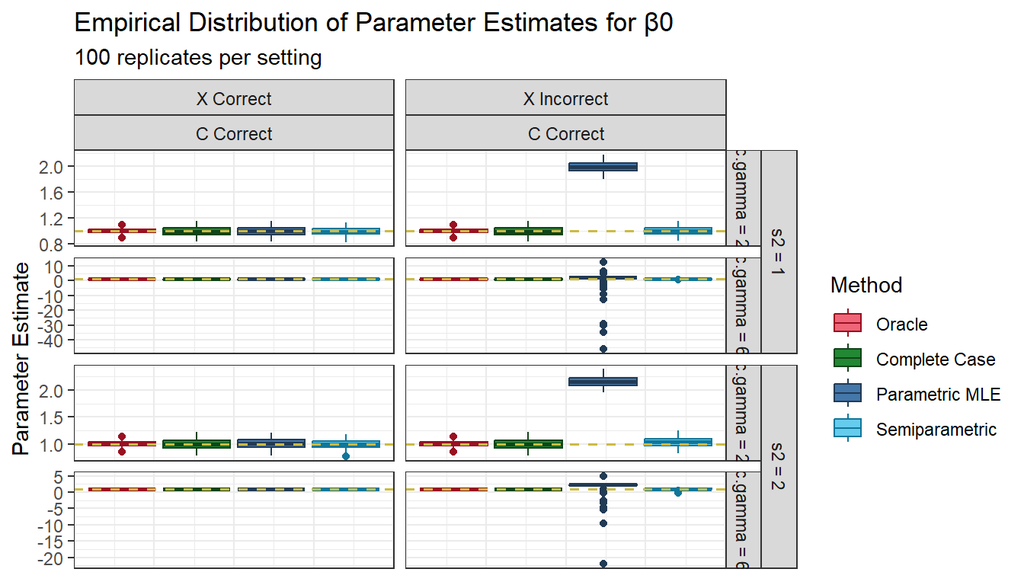

```r
make.est.plot(param. = 1)
```

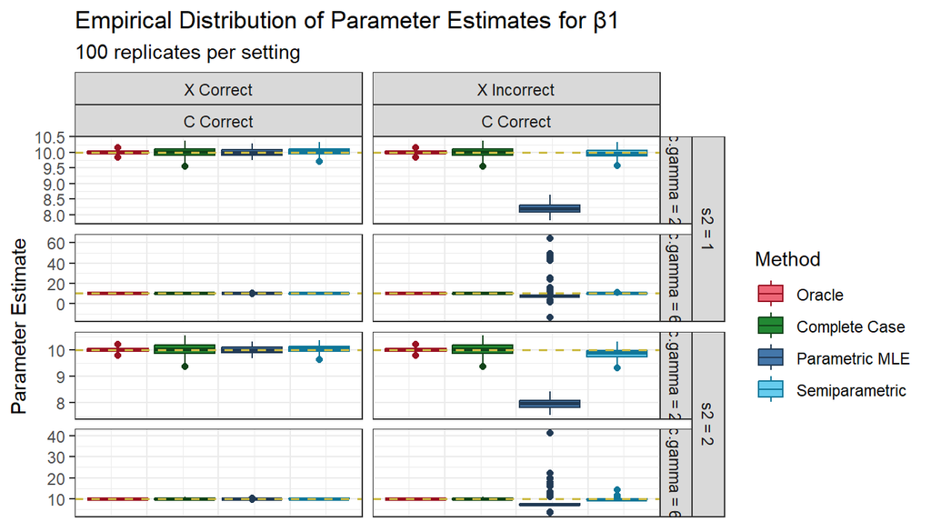

```r
make.est.plot(param. = 2)
```

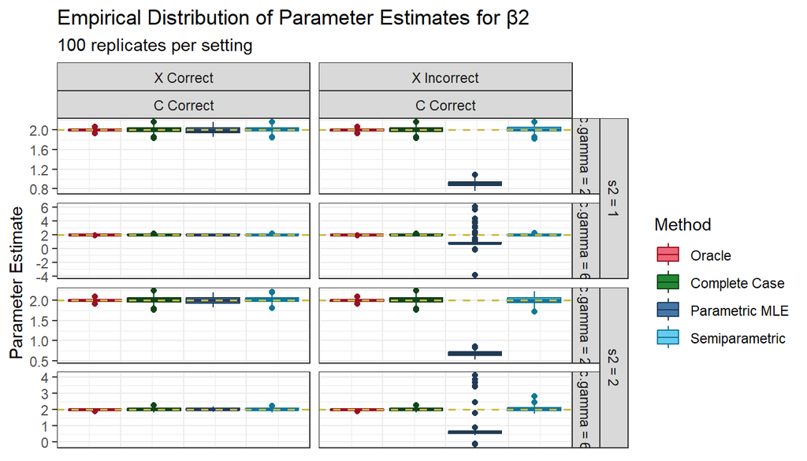

```r
make.est.plot(param. = 3)
```

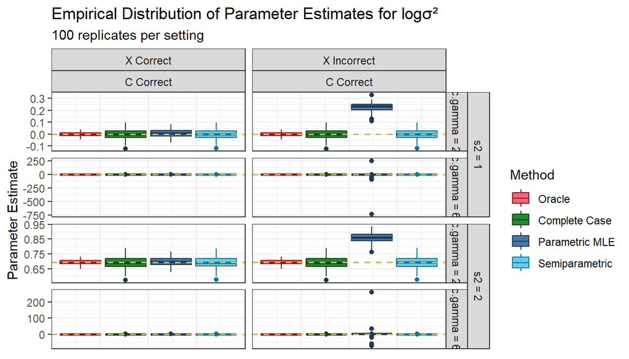

```r
make.est.plot(param. = 4)
```

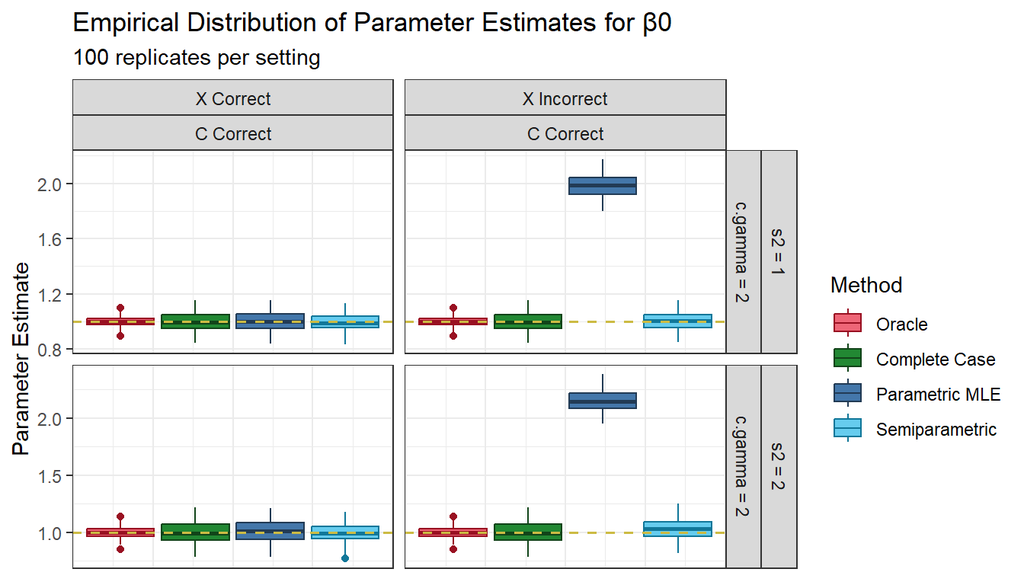

```r
make.est.plot(param. = 1, c.gamma. = c.gamma[1])
```

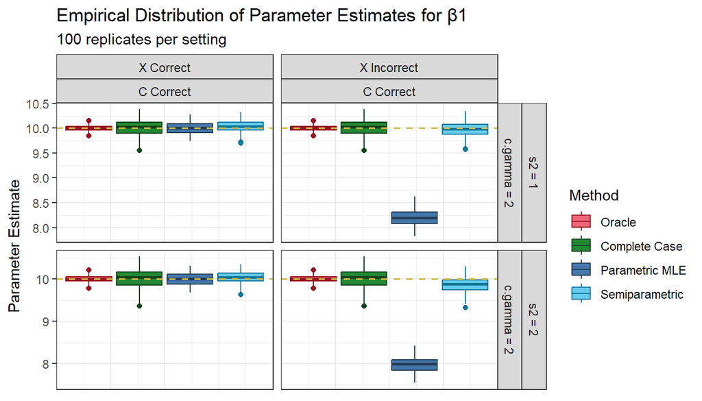

```r
make.est.plot(param. = 2, c.gamma. = c.gamma[1])
```

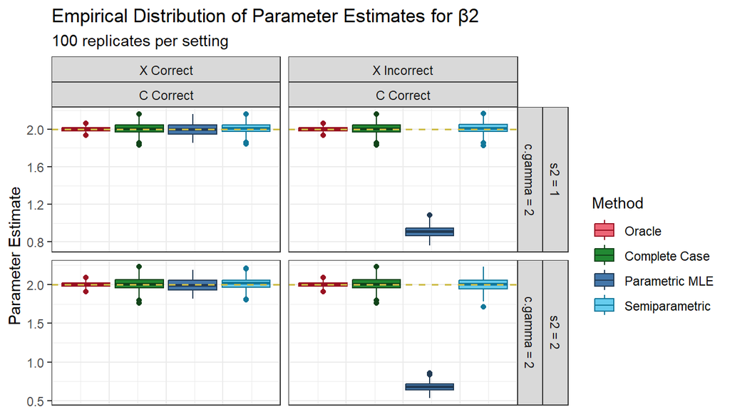

```r
make.est.plot(param. = 3, c.gamma. = c.gamma[1])
```

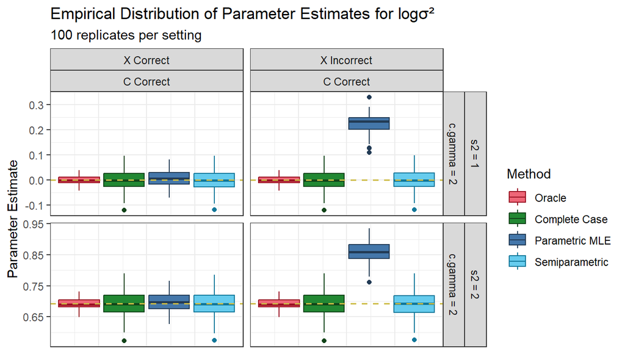

```r
make.est.plot(param. = 4, c.gamma. = c.gamma[1])
```

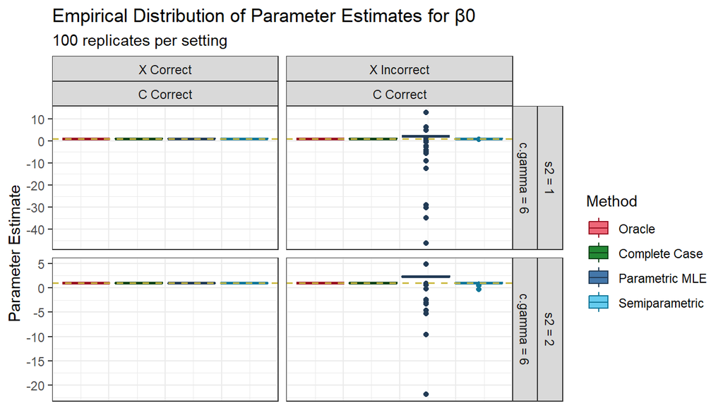

```r
make.est.plot(param. = 1, c.gamma. = c.gamma[2])
```

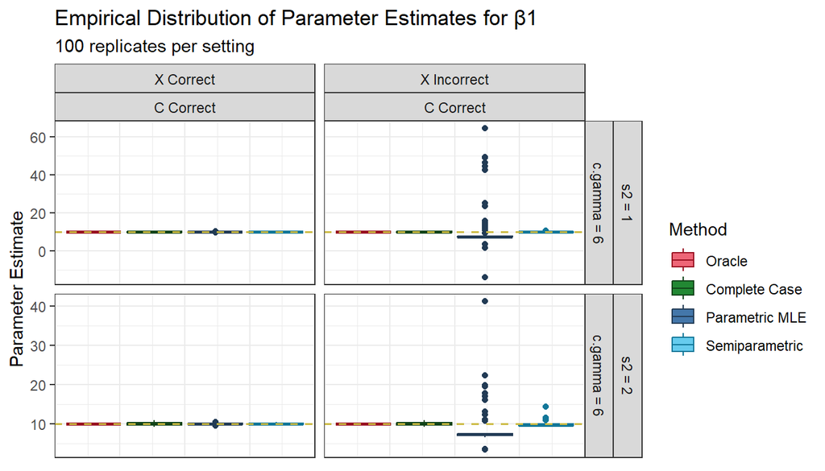

```r
make.est.plot(param. = 2, c.gamma. = c.gamma[2])
```

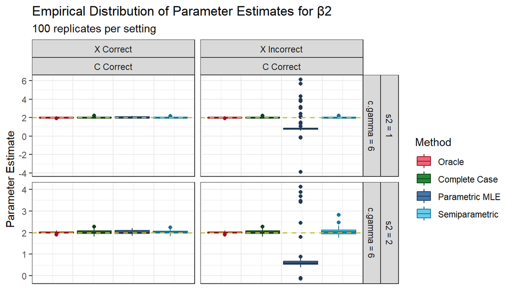

```r
make.est.plot(param. = 3, c.gamma. = c.gamma[2])
```

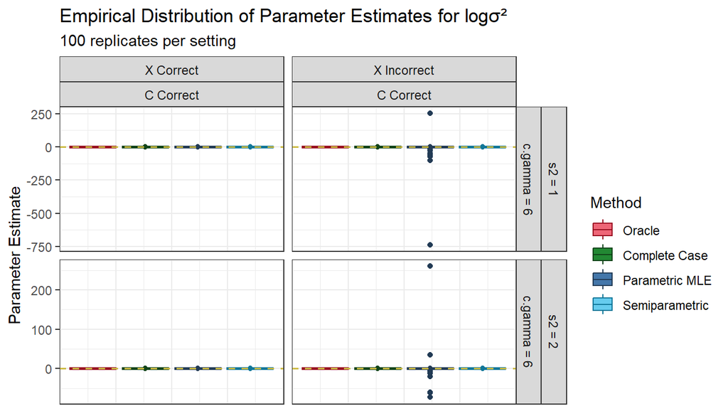

```r
make.est.plot(param. = 4, c.gamma. = c.gamma[2])
```

```r
# table summarizing for only beta2, and for q = 0.8
tbl2 <- sim.out.long %>%
  filter(param == 2,
         q == 0.8) %>%
  group_by(n, q, c.gamma, s2, x.correct, c.correct, method) %>%
  summarise(Bias = 100*mean(estimate - B.true, na.rm = T),
            Variance = 100*sd(estimate, na.rm = T),
            MSE = 100*mean((estimate - B.true) ^ 2, na.rm = T)) %>%
  gather(key, value, Bias:MSE) %>%
  unite(Group, c(x.correct, c.correct), key) %>%
  spread(Group, value)

setNames(tbl2, sub(".+_", "", names(tbl2))) %>%
  kable(digits = 1) %>%
  kable_styling("striped") %>%
  add_header_above(c(" " = 5,
                     #"Neither" = 3,
                     #"X Only" = 3,
                     "C Only" = 3,
                     "Both" = 3))
```

| n | q | c.gamma | s2 | method | C Only Bias | C Only MSE | C Only Variance | Both Bias | Both MSE | Both Variance |
| --- | --- | --- | --- | --- | --- | --- | --- | --- | --- | --- |
| 8000 | 0.8 | 2 | 1 | or | 0.0 | 0.3 | 5.2 | 0.0 | 0.3 | 5.2 |
| 8000 | 0.8 | 2 | 1 | cc | -0.2 | 2.9 | 17.1 | -0.2 | 2.9 | 17.1 |
| 8000 | 0.8 | 2 | 1 | ml | -179.9 | 326.4 | 17.1 | 0.5 | 1.3 | 11.5 |
| 8000 | 0.8 | 2 | 1 | sp | -3.8 | 2.7 | 16.0 | 1.7 | 1.9 | 13.7 |
| 8000 | 0.8 | 2 | 2 | or | -0.1 | 0.5 | 7.4 | -0.1 | 0.5 | 7.4 |
| 8000 | 0.8 | 2 | 2 | cc | -0.3 | 5.8 | 24.2 | -0.3 | 5.8 | 24.2 |
| 8000 | 0.8 | 2 | 2 | ml | -202.5 | 413.0 | 17.8 | -0.4 | 1.9 | 14.0 |
| 8000 | 0.8 | 2 | 2 | sp | -15.4 | 6.5 | 20.5 | 2.3 | 2.5 | 15.8 |
| 8000 | 0.8 | 6 | 1 | or | 0.5 | 0.3 | 5.2 | 0.5 | 0.3 | 5.2 |
| 8000 | 0.8 | 6 | 1 | cc | 0.4 | 5.0 | 22.6 | 0.4 | 5.0 | 22.6 |
| 8000 | 0.8 | 6 | 1 | ml | 38.3 | 11341.9 | 1069.7 | 2.7 | 1.6 | 12.5 |
| 8000 | 0.8 | 6 | 1 | sp | -2.0 | 5.6 | 23.8 | 3.1 | 2.8 | 16.5 |
| 8000 | 0.8 | 6 | 2 | or | 0.7 | 0.5 | 7.4 | 0.7 | 0.5 | 7.4 |
| 8000 | 0.8 | 6 | 2 | cc | 0.6 | 10.1 | 31.9 | 0.6 | 10.1 | 31.9 |
| 8000 | 0.8 | 6 | 2 | ml | -160.0 | 2222.7 | 445.7 | 2.5 | 2.3 | 15.0 |
| 8000 | 0.8 | 6 | 2 | sp | -14.0 | 37.9 | 60.2 | 4.2 | 3.4 | 18.0 |

#### All Simulation Results

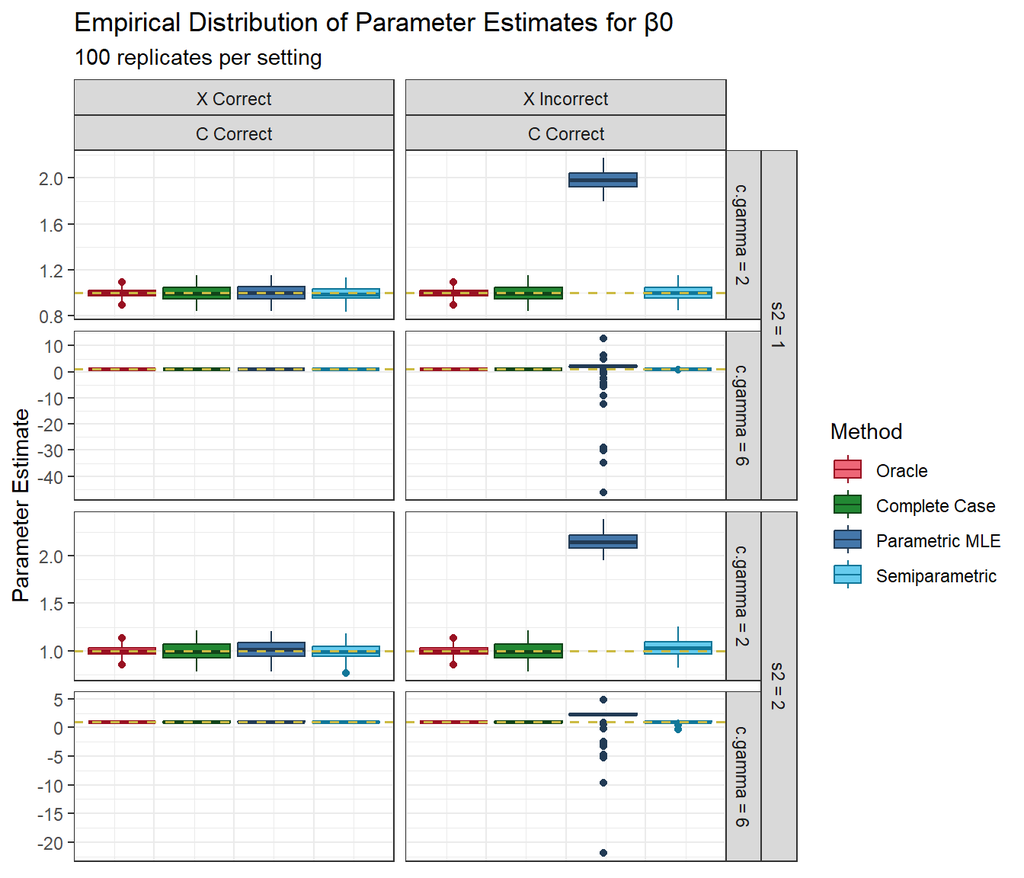

```r
make.est.plot(param. = 1)
```

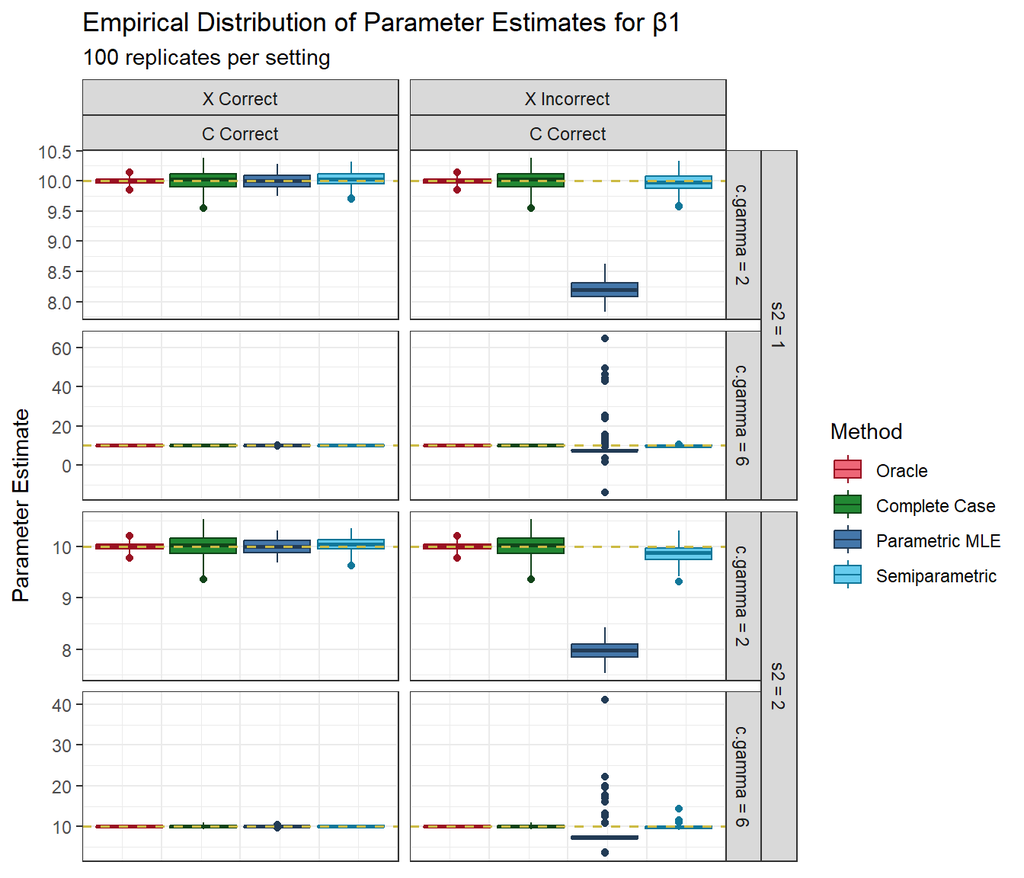

```r
make.est.plot(param. = 2)
```

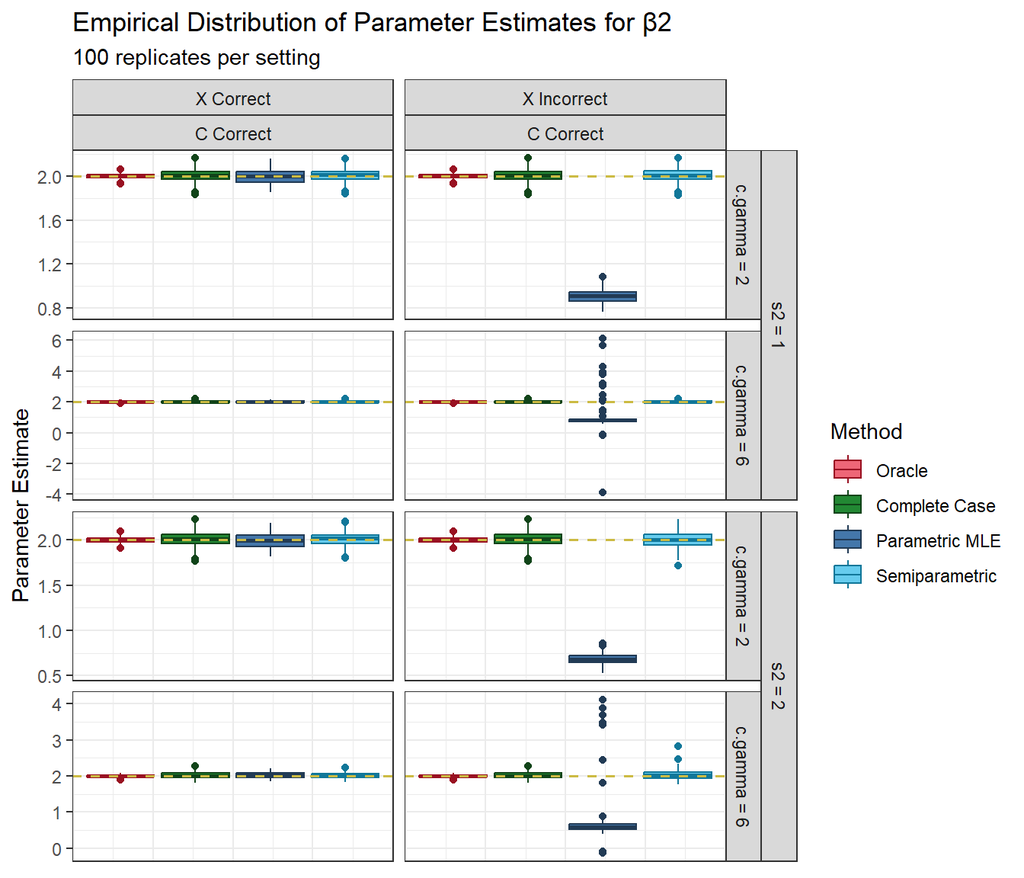

```r
make.est.plot(param. = 3)
```

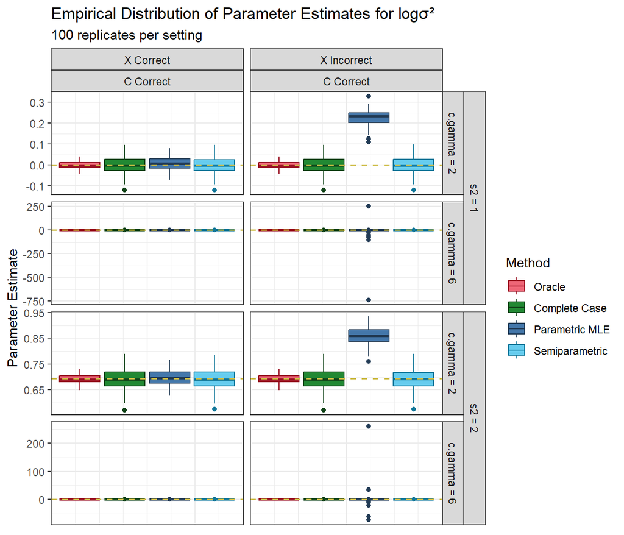

```r
make.est.plot(param. = 4)
```

```r
tbl <- sim.out.long %>%
  group_by(n, q, x.correct, c.correct, method, param) %>%
  summarise(Bias = 100*mean(estimate - B.true, na.rm = T),
            Variance = 100*var(estimate, na.rm = T),
            MSE = 100*mean((estimate - B.true) ^ 2, na.rm = T)) %>%
  gather(key, value, Bias:MSE) %>%
  unite(Group, c(x.correct, c.correct), key) %>%
  spread(Group, value)

setNames(tbl, sub(".+_", "", names(tbl))) %>%
  kable(digits = 1) %>%
  kable_styling("striped") %>%
  add_header_above(c(" " = 4,
                     "Neither" = 3,
                     "X Only" = 3,
                     "C Only" = 3,
                     "Both" = 3))
```

[output not shown]